# Session 1: Getting to Know Our Reef Tank

Stier Lab Coding Sessions

Author

## How to use this document

This is a **Quarto document**. It mixes regular text (like this) with **code chunks** (the gray boxes). You can run code three ways:

| To run | Do this |
| --- | --- |
| One line | Put your cursor on the line and press **Command + Enter** (Mac) or **Control + Enter** (Windows) |
| A whole chunk | Click the green ▶ arrow in the top right corner of the chunk |
| The whole document | Click **Render** at the top of this panel. This makes a web page (HTML) of your work. |

When you see `____` (a blank), replace it with your own code. Type your answers to the **Questions** in the space below each one, as regular text.

The data are readings every 10 minutes from October 9 to October 23, 2026, recorded by the tank’s Apex controller. See the `README.md` file for what each column means.

## Part 1: Load packages and data

Packages are add-ons that give R extra tools. You only install them once, but you load them with `library()` every time you open R. If you have not installed the tidyverse yet, run `install.packages("tidyverse")` once in the **Console** (bottom left), not in this document.

```r
library(tidyverse)
```

Next, read the tank data into R and store it as an object called `tank`. The arrow `<-` means “save the thing on the right under the name on the left.”

The `../` means “go up one folder.” This document lives in the `scripts` folder, so R has to go up one level to find the `data` folder.

```r
tank <- read_csv("../data/tank_data.csv")
```

## Part 2: Look at the data

See the first six rows:

```r
head(tank)
```

```
# A tibble: 6 × 15
  datetime            date        hour temperature    ph   orp salinity
  <dttm>              <date>     <dbl>       <dbl> <dbl> <dbl>    <dbl>
1 2026-10-09 00:00:00 2026-10-09     0        78.2  8.67   292     35.6
2 2026-10-09 00:10:00 2026-10-09     0        78.2  8.68   292     35.6
3 2026-10-09 00:20:00 2026-10-09     0        78.2  8.68   292     35.6
4 2026-10-09 00:30:00 2026-10-09     0        78.2  8.66   293     35.6
5 2026-10-09 00:40:00 2026-10-09     0        78.2  8.66   293     35.7
6 2026-10-09 00:50:00 2026-10-09     0        78.1  8.65   293     35.6
# ℹ 8 more variables: alkalinity <dbl>, calcium <dbl>, magnesium <dbl>,
#   light_watts <dbl>, heater_watts <dbl>, return_pump_watts <dbl>,
#   skimmer_watts <dbl>, uv_sterilizer_watts <dbl>
```

How many rows (readings) and columns (variables) are there?

```r
nrow(tank)
```

```
[1] 2123
```

```r
ncol(tank)
```

```
[1] 15
```

What are the column names?

```r
names(tank)
```

```
 [1] "datetime"            "date"                "hour"
 [4] "temperature"         "ph"                  "orp"
 [7] "salinity"            "alkalinity"          "calcium"
[10] "magnesium"           "light_watts"         "heater_watts"
[13] "return_pump_watts"   "skimmer_watts"       "uv_sterilizer_watts"
```

Get a quick summary of every column:

```r
summary(tank)
```

```
    datetime                           date                 hour
 Min.   :2026-10-09 00:00:00.00   Min.   :2026-10-09   Min.   : 0.00
 1st Qu.:2026-10-12 16:25:00.00   1st Qu.:2026-10-12   1st Qu.: 5.00
 Median :2026-10-16 08:50:00.00   Median :2026-10-16   Median :11.00
 Mean   :2026-10-16 08:56:56.01   Mean   :2026-10-15   Mean   :11.35
 3rd Qu.:2026-10-20 01:15:00.00   3rd Qu.:2026-10-20   3rd Qu.:17.00
 Max.   :2026-10-23 18:30:00.00   Max.   :2026-10-23   Max.   :23.00
  temperature          ph             orp           salinity
 Min.   :76.40   Min.   :8.630   Min.   :270.0   Min.   :35.00
 1st Qu.:78.20   1st Qu.:8.740   1st Qu.:291.0   1st Qu.:35.90
 Median :78.40   Median :8.770   Median :296.0   Median :36.00
 Mean   :78.39   Mean   :8.762   Mean   :295.1   Mean   :36.01
 3rd Qu.:78.70   3rd Qu.:8.790   3rd Qu.:299.0   3rd Qu.:36.10
 Max.   :79.30   Max.   :8.850   Max.   :307.0   Max.   :36.70
   alkalinity       calcium        magnesium     light_watts
 Min.   :6.650   Min.   :348.0   Min.   :1249   Min.   :  4.00
 1st Qu.:7.810   1st Qu.:362.0   1st Qu.:1254   1st Qu.:  6.00
 Median :8.600   Median :376.0   Median :1258   Median : 12.00
 Mean   :8.274   Mean   :374.6   Mean   :1258   Mean   : 32.88
 3rd Qu.:8.850   3rd Qu.:386.0   3rd Qu.:1262   3rd Qu.: 59.00
 Max.   :8.960   Max.   :396.0   Max.   :1267   Max.   :155.00
  heater_watts    return_pump_watts skimmer_watts  uv_sterilizer_watts
 Min.   :  0.00   Min.   : 0.0      Min.   : 0.0   Min.   : 0.00
 1st Qu.:  0.00   1st Qu.:49.0      1st Qu.:20.0   1st Qu.:23.00
 Median :  0.00   Median :50.0      Median :21.0   Median :23.00
 Mean   : 19.15   Mean   :48.6      Mean   :20.5   Mean   :20.62
 3rd Qu.:  0.00   3rd Qu.:52.0      3rd Qu.:21.0   3rd Qu.:23.00
 Max.   :244.00   Max.   :73.0      Max.   :27.0   Max.   :25.00
```

You can also open the whole table in a spreadsheet-style viewer by typing `View(tank)` in the **Console**, or by clicking `tank` in the **Environment** panel (top right).

### Question 1

How many readings are in this dataset? If the Apex records one reading every 10 minutes, roughly how many days does that cover?

**Answer:**

## Part 3: Ask the data questions

The `$` symbol pulls one column out of a table:

```r
head(tank$temperature)
```

```
[1] 78.2 78.2 78.2 78.2 78.2 78.1
```

Functions take something in and give something back:

```r
mean(tank$temperature)
```

```
[1] 78.39487
```

```r
min(tank$temperature)
```

```
[1] 76.4
```

```r
max(tank$temperature)
```

```
[1] 79.3
```

### Question 2

What was the average pH? The lowest? The highest? Fill in the blanks, then run the chunk.

```r
mean(tank$____)
min(tank$____)
max(tank$____)
```

```
Error in parse(text = input): <text>:1:11: unexpected input
1: mean(tank$_
              ^
```

**Answer:**

### Question 3

Reef tanks are usually kept between 76 and 80 degrees Fahrenheit. Did our tank ever leave that range?

**Answer:**

## Part 4: Your first plot

`ggplot` builds plots in layers:

- `ggplot(data, aes(x = ..., y = ...))` says **what** to plot
- `+ geom_line()` says **how** to draw it

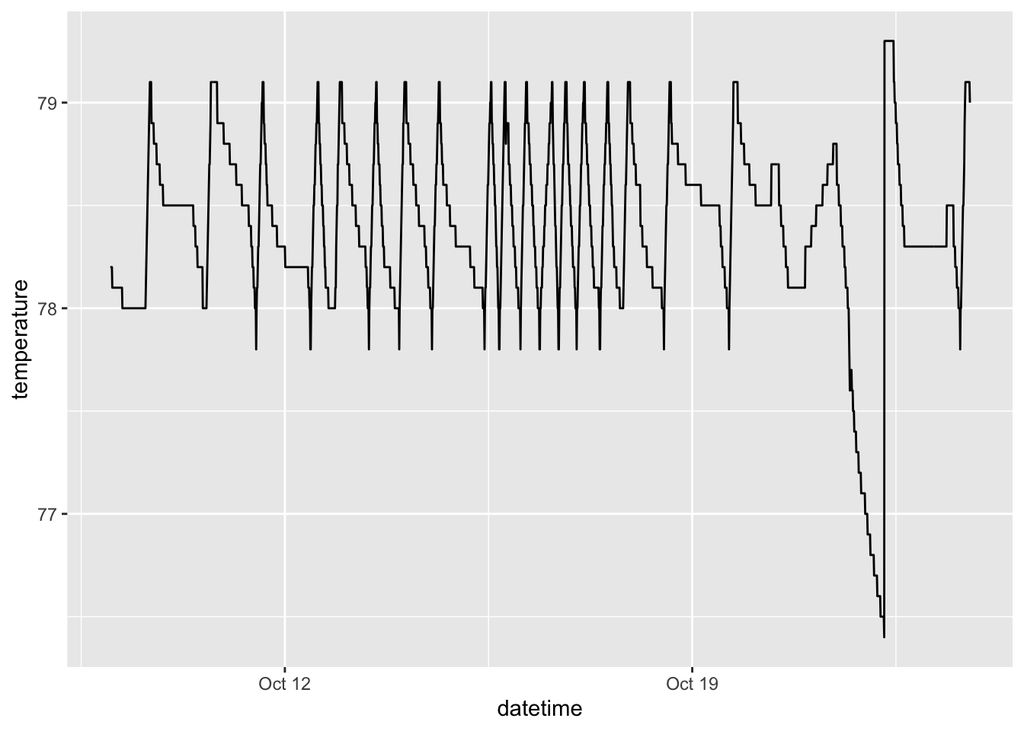

```r
ggplot(tank, aes(x = datetime, y = temperature)) +
  geom_line()
```

Make it nicer with labels:

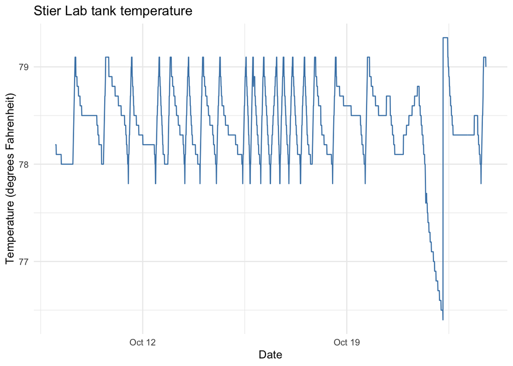

```r
ggplot(tank, aes(x = datetime, y = temperature)) +
  geom_line(color = "steelblue") +
  labs(x = "Date",
       y = "Temperature (degrees Fahrenheit)",
       title = "Stier Lab tank temperature") +
  theme_minimal()
```

## Part 5: Tank detective

Something unusual happened in the tank around October 21 and 22. Look back at your temperature plot. Do you see it?

Some background on how the tank is set up:

- The **display tank** (where the corals live) holds the **heater**.
- The **sump** (the tank underneath) holds the **temperature probe**.
- The **return pump** pushes water from the sump up to the display, and the water drains back down into the sump. When the pump stops, the two tanks stop mixing.

Plot how much power the return pump used:

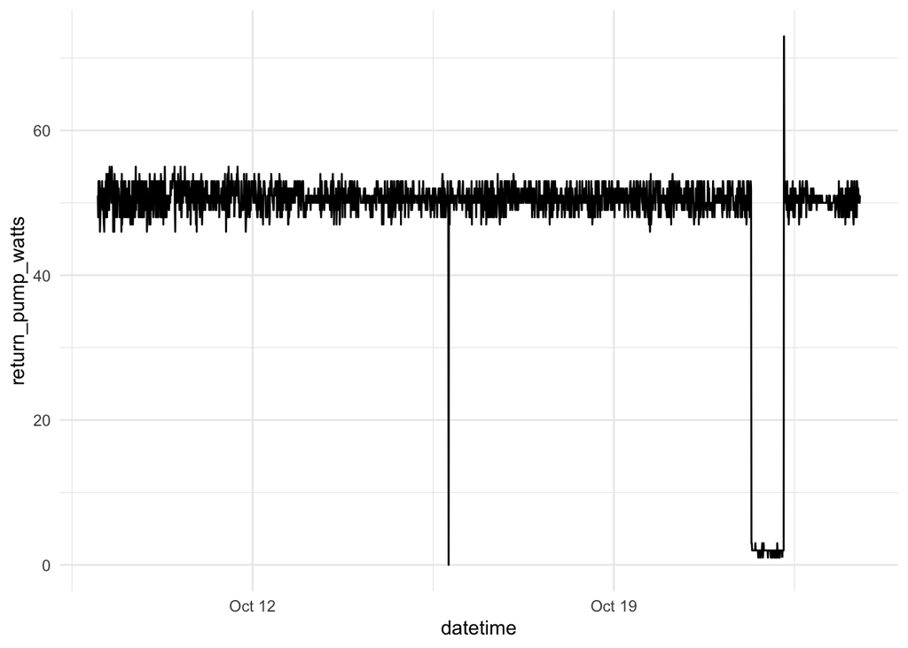

```r
ggplot(tank, aes(x = datetime, y = return_pump_watts)) +
  geom_line() +
  theme_minimal()
```

### Question 4

What happened to the return pump? Roughly when did it stop and start again?

**Answer:**

### Question 5

During the outage, the temperature reading slowly dropped. Then, within 10 minutes of the pump coming back on, it suddenly jumped **up** by almost 3 degrees. Why do you think that happened?

*Hint: think about where the heater is and where the probe is.*

**Answer:**

Now plot `heater_watts` over time. Does it support your explanation?

### Question 6

The Apex turns the heater on whenever the probe reads too cold. How often was the heater on during the outage compared to a normal day? What might that have done to the corals in the display tank?

**Answer:**

## Part 6: Day and night

The `hour` column tells you the hour of the day (0 is midnight, 13 is 1 p.m.). This plots every light reading by hour of the day:

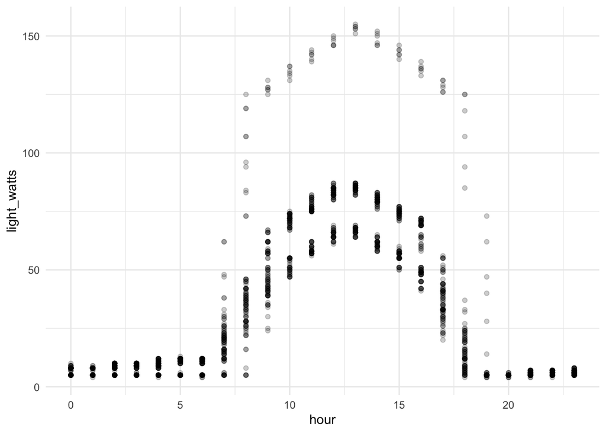

```r
ggplot(tank, aes(x = hour, y = light_watts)) +
  geom_point(alpha = 0.2) +
  theme_minimal()
```

### Question 7

When do the lights turn on and off? When are they brightest?

**Answer:**

Now make the same kind of plot for `orp` (oxidation reduction potential, a measure of how well the water can break down waste). Fill in the blank:

```r
ggplot(tank, aes(x = hour, y = ____)) +
  geom_point(alpha = 0.2) +
  theme_minimal()
```

```
Error in parse(text = input): <text>:1:33: unexpected input
1: ggplot(tank, aes(x = hour, y = __
                                    ^
```

### Question 8

What happens to `orp` when the lights come on in the morning?

**Answer:**

## Challenges (if you finish early)

**A.** Plot `alkalinity` over time. The Trident tester only measures it every 6 hours, which is why the line looks like stairs. What trend do you see?

**B.** Plot `temperature` (x) against `salinity` (y) with `geom_point()`. Should water temperature change how salty the water is? What might be going on with the salinity probe?

**C.** Calculate the average temperature for each hour of the day:

```r
tank |>
  group_by(hour) |>
  summarize(mean_temperature = mean(temperature))
```

```
# A tibble: 24 × 2
    hour mean_temperature
   <dbl>            <dbl>
 1     0             78.3
 2     1             78.4
 3     2             78.4
 4     3             78.4
 5     4             78.4
 6     5             78.3
 7     6             78.2
 8     7             78.3
 9     8             78.4
10     9             78.4
# ℹ 14 more rows
```

## Last step: save your work to GitHub

1. Change `author: "Your Name"` at the very top of this document to your name.
2. Click **Render** to make sure everything runs. Any red error messages in the rendered page point to chunks to fix.
3. Save this file (**Command + S** or **Control + S**).
4. In the **Git** tab (top right of RStudio), check the box next to `01_tank_intro.qmd`.
5. Click **Commit**, write a short message like “Finished session 1 activity,” and click **Commit** again.
6. Click **Push** (the green up arrow).